# Movie Genre Popularity and Economic Activity

## Introduction

Consumer sentiment plays an important role in driving economic activity. The effects of economic activity are reflected in the stock market. Positive consumer sentiment leads to high spending that leads to the appreciation of a company's share price. Inversely, negative consumer sentiment leads to less spending and depreciating share price.

One way of measuring consumer sentiment may be in the media they consume. Specifically with movies, the popularity of genres being produced and watched by consumers may reflect general consumer sentiment. After all, people do seek out specific genres, such as comedy, romance, or action, based on their moods.

Thee popularity of a genre may act as a contrarian indicator of consumer sentiment and negatively correlate with economic activity and stock performance. Alternatively, the popularity of a genre might reflect the attitude of customers at that time and positive correlate with economic activity and stock performance. A strong correlation, either negative or positive, may indicate a predictive or reactive relationship between genre popularity and economic activity. Such information could be valuable in making investment decisions or diagnosing economic health.

```python
import numpy as np
import pandas as pd
import datetime
import matplotlib.pyplot as plt
from sklearn import preprocessing
from sklearn import linear_model
```

```python
# set visualization parameters
plt.rcParams['figure.figsize'] = [12, 8]
RED = "#FFA69E"
ORANGE = "#E6C79C"
YELLOW = "#CDDFA0"
GREEN = "#6FD08C"
BLUE = "#7B9EA8"
PURPLE = "#78586F"
PINK = "#ED254E"
```

## Data Collection and Data Tidying

First, I'll read in the relevant datasets and preprocess them in order to match our expository objectives.

### Financial Data

In order to measure general economic activity, I'll utilize the S&P 500 Index. The S&P 500 is an index of the 500 largest publicly traded companies in the United States weighted by market capitalization, the size of company in dollars. Some of the companies in the S&P 500 are younger, such as Alphabet (Google), Amazon, and Facebook, while others are older, such as Disney, General Electric, and Ford. When the share prices of companies in the index depreciate, so does the index as a whole. Likewise, when the share price of companies appreciate, so does the index.

[Read More: About the S&P 500](https://www.investopedia.com/terms/s/sp500.asp)

The S&P 500 data is available on [Yahoo Finance](https://finance.yahoo.com/quote/%5EGSPC/history) in .csv format. The dataset contains daily-resolution index data from 1920 onwards. In order to make the dataset most relevant to our analysis, I have limited the data to the past 50 years, from 1970 onwards. Furthermore, I transformed the 'Date' column to a datetime format in order to improve functionality later.

```python
# data source: https://finance.yahoo.com/quote/%5EGSPC/history
sp500_df = pd.read_csv("sp500.csv")
sp500_df["Date"] = pd.to_datetime(sp500_df["Date"]) # cast to datetime
sp500_df = sp500_df[sp500_df["Date"] > datetime.datetime(1970, 1, 1, 0, 0)] # after 1970
```

Here's some data from 1970:

```python
sp500_df.head()
```

|  | Date | Open | High | Low | Close | Adj Close | Volume |
| --- | --- | --- | --- | --- | --- | --- | --- |
| 10496 | 1970-01-02 | 92.059998 | 93.540001 | 91.790001 | 93.000000 | 93.000000 | 8050000 |
| 10497 | 1970-01-05 | 93.000000 | 94.250000 | 92.529999 | 93.459999 | 93.459999 | 11490000 |
| 10498 | 1970-01-06 | 93.459999 | 93.809998 | 92.129997 | 92.820000 | 92.820000 | 11460000 |
| 10499 | 1970-01-07 | 92.820000 | 93.379997 | 91.930000 | 92.629997 | 92.629997 | 10010000 |
| 10500 | 1970-01-08 | 92.629997 | 93.470001 | 91.989998 | 92.680000 | 92.680000 | 10670000 |

Here is some more recent data.

```python
sp500_df.tail()
```

|  | Date | Open | High | Low | Close | Adj Close | Volume |
| --- | --- | --- | --- | --- | --- | --- | --- |
| 23346 | 2020-12-09 | 3705.979980 | 3712.389893 | 3660.540039 | 3672.820068 | 3672.820068 | 5209940000 |
| 23347 | 2020-12-10 | 3659.129883 | 3678.489990 | 3645.179932 | 3668.100098 | 3668.100098 | 4618240000 |
| 23348 | 2020-12-11 | 3656.080078 | 3665.909912 | 3633.399902 | 3663.459961 | 3663.459961 | 4367150000 |
| 23349 | 2020-12-14 | 3675.270020 | 3697.610107 | 3645.840088 | 3647.489990 | 3647.489990 | 4594920000 |
| 23350 | 2020-12-15 | 3666.409912 | 3695.290039 | 3659.620117 | 3694.620117 | 3694.620117 | 4360280000 |

For my analysis, I utilize 'Adj Close'. 'Adj Close' is the adjusted value of the index at 4:00 PM, the end of the trading day. The adjusted close accounts for corporate actions that affect the raw share price but not the share value. Events such as these (stock splits, dividends, etc.) are beyond the scope of this analysis.

[Read More: What is the Adjusted Closing Price?](https://www.investopedia.com/terms/a/adjusted_closing_price.asp)

Here's a graph of the index's daily performance from 1970 to today:

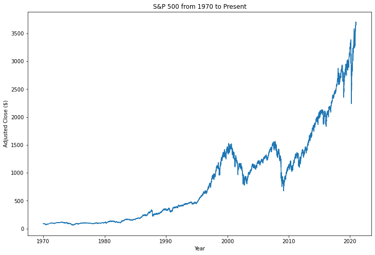

```python
# plot SP 500 over time
plt.title("S&P 500 from 1970 to Present")
plt.xlabel("Year")
plt.ylabel("Adjusted Close ($)")
plt.plot(sp500_df["Date"], sp500_df["Adj Close"])
plt.show()
```

You can see the impact of several global economic and political events such as the Crash of 1987, the effects of the Dot Com Bubble + the September 11th attacks, the 2008 Financial Crisis, the 2018 Trade War, and the 2020 COVID-19 pandemic.

[Read More: The worst stock market crashes of all time, and why they happened](https://www.ig.com/en/trading-strategies/the-worst-stock-market-crashes-of-all-time-181031)

### Movie Data

The data I used for movies is available on [IMBD](https://datasets.imdbws.com/). The dataset includes entries for non-movie media such as TV shows, short films, and other misc. video. Thus, I preprocess the data in several ways. First, I remove all entries where the runtime, the genre, or the start year is unknown. Next, I transform the start year and runtime columns to from text to numeric. Then, I filter the dataset down to just movies with a runtime of 1 hour or greater. Lastly, I limit movies to titles in the 1970 to 2020 range to match the finanicial data.

```python
# data source: https://datasets.imdbws.com/
imbd_df = pd.read_csv("imbd.tsv", sep ="\t")
imbd_df = imbd_df[(imbd_df["runtimeMinutes"] != "\\N") & (imbd_df["genres"] != "\\N") & (imbd_df["startYear"] != "\\N")] #  remove unknowns
```

```python
movies_df = imbd_df[(imbd_df["titleType"] == "movie")] # get only movies
movies_df = movies_df.astype({"startYear": int, "runtimeMinutes": int}) # cast from text to numeric
movies_df = movies_df[movies_df["runtimeMinutes"] >= 60] # runtime greater than or equalt to 1 hour
movies_df = movies_df[(movies_df["startYear"] >= 1970) & (movies_df["startYear"] <= 2020)] # movies from 1970 to 2020
```

Here is a random sample of the resulting dataset:

```python
movies_df.sample(5)
```

|  | tconst | titleType | primaryTitle | originalTitle | isAdult | startYear | endYear | runtimeMinutes | genres |
| --- | --- | --- | --- | --- | --- | --- | --- | --- | --- |
| 81001 | tt0082764 | movie | Modern Romance | Modern Romance | 0 | 1981 | \N | 93 | Comedy,Romance |
| 3088211 | tt1399186 | movie | Ei Prithibi Tomar Aamar | Ei Prithibi Tomar Aamar | 0 | 2009 | \N | 130 | Drama,Musical,Romance |
| 3535883 | tt1865505 | movie | Song of the Sea | Song of the Sea | 0 | 2014 | \N | 93 | Adventure,Animation,Drama |
| 143756 | tt0148097 | movie | The Edge of Power | The Edge of Power | 0 | 1987 | \N | 94 | Thriller |
| 208501 | tt0217136 | movie | Pretty Devils | Voyous voyelles | 0 | 1999 | \N | 95 | Comedy,Drama |

Here's a the number of movies produced by year from 1970 to 2020:

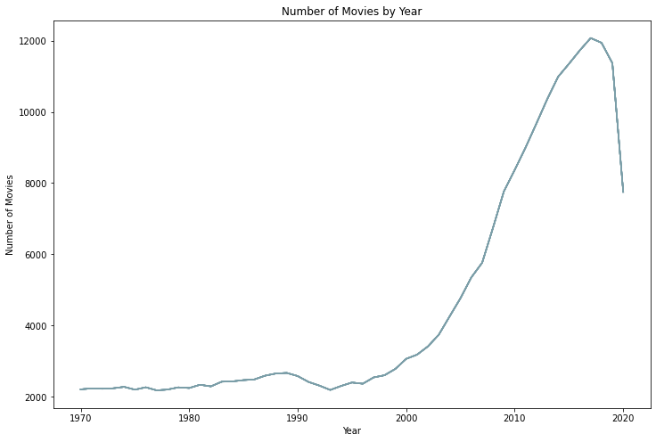

```python
movie_count_df = movies_df.groupby("startYear").count() # group by movie year, the count total
plt.title("Number of Movies by Year")
plt.xlabel("Year")
plt.ylabel("Number of Movies")
plt.plot(movie_count_df, color = BLUE)
plt.show()
```

You can see that movies became very popular after 2000, perhaps the effects of production equipment becoming cheaper over time and distribution becoming simpler due to the Internet. You can also see the impact of the 2020 COVID-19 pandemic, as theatres closed, forcing studios to push their movies to release in 2021 and onwards.

[Read More: Impact of COVID-19 on Cinemas](https://en.wikipedia.org/wiki/Impact_of_the_COVID-19_pandemic_on_cinema)

## Exploratory Data Analysis

### Normalizing Movie Data

Below is the number of movies for some popular genres over time. I've chosen the 7 most popular genres: Comedy, Horror, Romance, Action, Thriller, Drama, and Mystery:

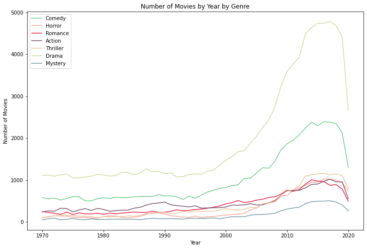

```python
# popular genres compared
# filter by genre
comedy_df = movies_df[movies_df["genres"].str.contains("Comedy")]
horror_df = movies_df[movies_df["genres"].str.contains("Horror")]
romance_df = movies_df[movies_df["genres"].str.contains("Romance")]
action_df = movies_df[movies_df["genres"].str.contains("Action")]
thriller_df = movies_df[movies_df["genres"].str.contains("Thriller")]
drama_df = movies_df[movies_df["genres"].str.contains("Drama")]
mystery_df = movies_df[movies_df["genres"].str.contains("Mystery")]

# plot total counts
plt.title("Number of Movies by Year by Genre")
plt.xlabel("Year")
plt.ylabel("Number of Movies")
plt.plot(comedy_df.groupby("startYear").count()["tconst"], color = GREEN, label = "Comedy")
plt.plot(horror_df.groupby("startYear").count()["tconst"], color = RED, label = "Horror")
plt.plot(romance_df.groupby("startYear").count()["tconst"], color = PINK, label = "Romance")
plt.plot(action_df.groupby("startYear").count()["tconst"], color = PURPLE, label = "Action")
plt.plot(thriller_df.groupby("startYear").count()["tconst"], color = ORANGE, label = "Thriller")
plt.plot(drama_df.groupby("startYear").count()["tconst"], color = YELLOW, label = "Drama")
plt.plot(mystery_df.groupby("startYear").count()["tconst"], color = BLUE, label = "Mystery")
plt.legend(loc = "upper left")
plt.show()
```

[Read More: Min-Max Normalization and other normalization techniques](https://www.codecademy.com/articles/normalization)

```python
def get_normalized_df(df):
    count_df = df.groupby("startYear").count()
    count_df = count_df[["tconst"]]
    return (count_df - count_df.mean())/(count_df.max() - count_df.min()) # min max normalization

# normalize movies
comedy_count_norm_df = get_normalized_df(comedy_df)
horror_count_norm_df = get_normalized_df(horror_df)
romance_count_norm_df = get_normalized_df(romance_df)
action_count_norm_df = get_normalized_df(action_df)
thriller_count_norm_df = get_normalized_df(thriller_df)
drama_count_norm_df = get_normalized_df(drama_df)
mystery_count_norm_df = get_normalized_df(mystery_df)
movie_count_norm_df = get_normalized_df(movies_df)
```

Below is a plot of the normalized movie data by genre:

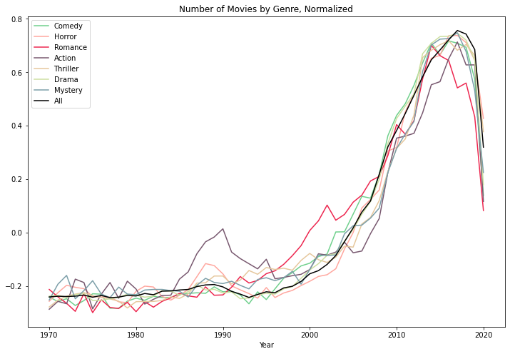

```python
# plot normalized
plt.title("Number of Movies by Genre, Normalized")
plt.xlabel("Year")
plt.plot(comedy_count_norm_df, color = GREEN, label = "Comedy")
plt.plot(horror_count_norm_df, color = RED, label = "Horror")
plt.plot(romance_count_norm_df, color = PINK, label = "Romance")
plt.plot(action_count_norm_df, color = PURPLE, label = "Action")
plt.plot(thriller_count_norm_df, color = ORANGE, label = "Thriller")
plt.plot(drama_count_norm_df, color = YELLOW, label = "Drama")
plt.plot(mystery_count_norm_df, color = BLUE, label = "Mystery")
plt.plot(movie_count_norm_df, color = "black", label = "All")
plt.legend(loc = "upper left")
plt.show()
```

Interestingly, we see a spike in Action movies from the mid 80s to the mid 90s. Most likely, this is studios trying to capitalize on the success of other well recieved action movie franchises, such as The Terminator (1984), Predator (1987), and Die Hard (1988), among others. There's also a similar spike for Romance movies from the mid 90s to the mid 2000s. Similarly, theres an early drop off in the Romance genre, although the reason for this is unknown.

[Read More: NYT on American Action Movies](https://www.nytimes.com/2012/04/01/magazine/how-the-american-action-movie-went-kablooey.html)

### Relative Genre Popularity

Normalizing is helpful, but in order to determine if a certain genre predicts or reacts to consumer sentiment, I need to determine how popular it is relative to other genres at the time. The best way to do this is to take the normalized genre values and subtract the normalized values of all movies to calculate the genre's excess popularity for that year.

```python
# comedies excess of normal movies
def get_genre_excess_df(count_norm_df, movie_count_norm_df):
    excess_df = count_norm_df.copy()
    excess_df["excess"] = excess_df["tconst"] - movie_count_norm_df["tconst"] # get excess
    excess_df = excess_df[["excess"]] # remove all other columns

    return excess_df

# get genre excess popularity
comedy_excess_df = get_genre_excess_df(comedy_count_norm_df, movie_count_norm_df)
horror_excess_df = get_genre_excess_df(horror_count_norm_df, movie_count_norm_df)
romance_excess_df = get_genre_excess_df(romance_count_norm_df, movie_count_norm_df)
action_excess_df = get_genre_excess_df(action_count_norm_df, movie_count_norm_df)
thriller_excess_df = get_genre_excess_df(thriller_count_norm_df, movie_count_norm_df)
drama_excess_df = get_genre_excess_df(drama_count_norm_df, movie_count_norm_df)
mystery_excess_df = get_genre_excess_df(mystery_count_norm_df, movie_count_norm_df)
```

Below is a plot of a genre's popularity excess for that year.

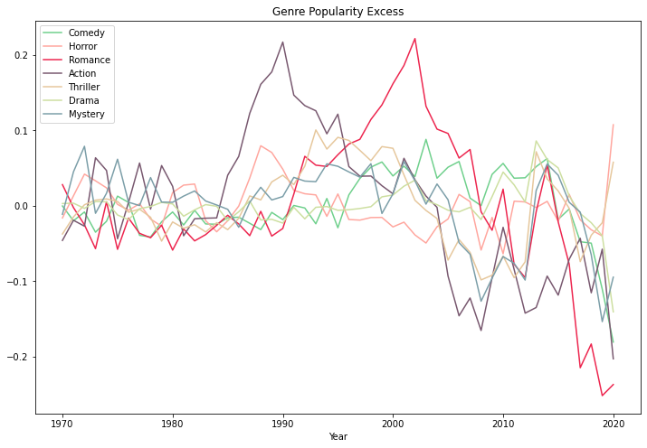

```python
# plot popularity excess
plt.title("Genre Popularity Excess")
plt.xlabel("Year")
plt.plot(comedy_excess_df, color = GREEN, label = "Comedy")
plt.plot(horror_excess_df, color = RED, label = "Horror")
plt.plot(romance_excess_df, color = PINK, label = "Romance")
plt.plot(action_excess_df, color = PURPLE, label = "Action")
plt.plot(thriller_excess_df, color = ORANGE, label = "Thriller")
plt.plot(drama_excess_df, color = YELLOW, label = "Drama")
plt.plot(mystery_excess_df, color = BLUE, label = "Mystery")
plt.legend(loc = "upper left")
plt.show()
```

The above visualization really illustrates the meteoric rise in popularity of the Action genre from the mid 80s to the mid 90s in comparison to the previous visualization. It also shows a similar phenomenon for the Romance genre from the mid 90s to the mid 2000s. What is more apparent now is that following the rise of these genres is a proportionate fall in popularity. Perhaps audiences and studios exhuast a genre by repetition, leading to its subsequent decline in popularity. The exact reason this occurs is outside the scope of this analysis.

### Normalizing the Financial Data

In order to make the movie data and financial data comparable, I must also normalize the S&P 500 data. First, I'll calculate the annual return. Then, I'll normalize those returns.

```python
# get annual returns basedon daily returns
def get_annual_returns_df(df):
    df["Daily Return"] = df.groupby(df.Date.dt.year)["Adj Close"].apply(pd.Series.pct_change)
    return_df = df.groupby(df.Date.dt.year)["Daily Return"].sum().mul(100).reset_index().rename(columns = {"Daily Return": "Annual Return"})
    return_df = return_df.set_index("Date")
    return return_df

# normalize, min max
def get_normalized_returns_df(df):
    return (df - df.mean())/(df.max() - df.min())

sp500_return_df = get_annual_returns_df(sp500_df)
sp500_return_norm_df = get_normalized_returns_df(sp500_return_df)
```

Below is a plot of normalized S&P 500 returns, alongside the genre popularity excess:

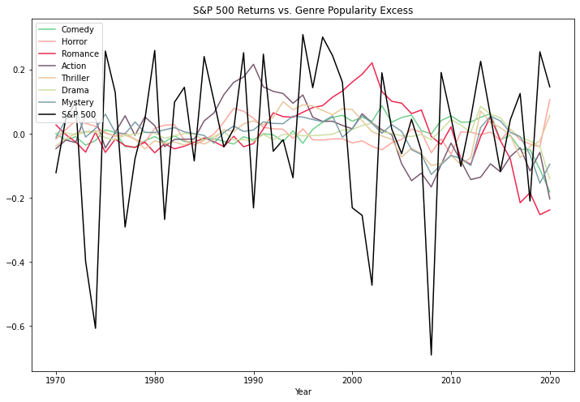

```python
# plot normalized returns
plt.title("S&P 500 Returns vs. Genre Popularity Excess")
plt.xlabel("Year")
plt.plot(comedy_excess_df, color = GREEN, label = "Comedy")
plt.plot(horror_excess_df, color = RED, label = "Horror")
plt.plot(romance_excess_df, color = PINK, label = "Romance")
plt.plot(action_excess_df, color = PURPLE, label = "Action")
plt.plot(thriller_excess_df, color = ORANGE, label = "Thriller")
plt.plot(drama_excess_df, color = YELLOW, label = "Drama")
plt.plot(mystery_excess_df, color = BLUE, label = "Mystery")
plt.plot(sp500_return_norm_df, color = "black", label = "S&P 500")
plt.legend(loc = "upper left")
plt.show()
```

### Correlating Returns with Popularity Excess

With the normalized S&P 500 returns and the genre popularity excess, I can determine if the popularity of a genre correlates with economic activity.

```python
def get_corr(returns_norm_df, excess_df):
    return returns_norm_df["Annual Return"].corr(excess_df["excess"])

# SP 500
spy_corr_df = pd.DataFrame(data = {
    "Genre": ["Comedy", "Horror", "Romance", "Action", "Thriller", "Drama", "Mystery"],
    "Correlation": [
        get_corr(sp500_return_norm_df, comedy_excess_df),
        get_corr(sp500_return_norm_df, horror_excess_df),
        get_corr(sp500_return_norm_df, romance_excess_df),
        get_corr(sp500_return_norm_df, action_excess_df),
        get_corr(sp500_return_norm_df, thriller_excess_df),
        get_corr(sp500_return_norm_df, drama_excess_df),
        get_corr(sp500_return_norm_df, mystery_excess_df)
    ]
})
spy_corr_df = spy_corr_df.set_index("Genre")
spy_corr_df
```

| Genre | Correlation |
| --- | --- |
| Comedy | 0.034995 |
| Horror | 0.116543 |
| Romance | -0.150252 |
| Action | 0.045455 |
| Thriller | 0.179803 |
| Drama | -0.095567 |
| Mystery | 0.099942 |

Below are the S&P 500 Returns as they correlate to the genre's popularity excess:

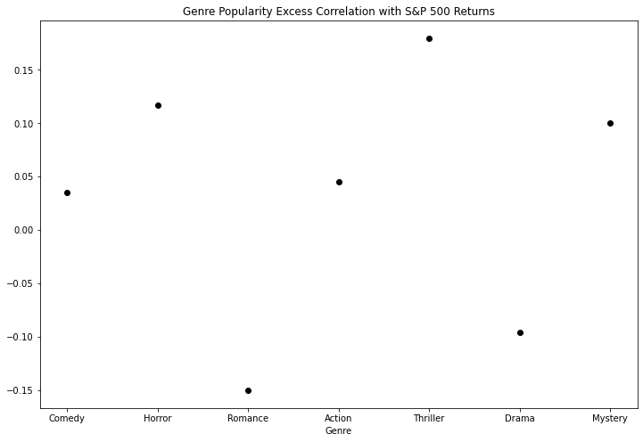

```python
plt.title("Genre Popularity Excess Correlation with S&P 500 Returns")
plt.xlabel("Genre")
plt.plot(spy_corr_df, "o", color = "black")
plt.show()
```

The correlation between genre popularity and S&P 500 returns is pretty weak. Thriller movies correlate the best postively with a 0.180 correlation coefficient, while Romance movies correlate the best negatively with a -0.150 correlation coefficient.

Below is the genre's relative popularity in comparison to S&P 500 returns.

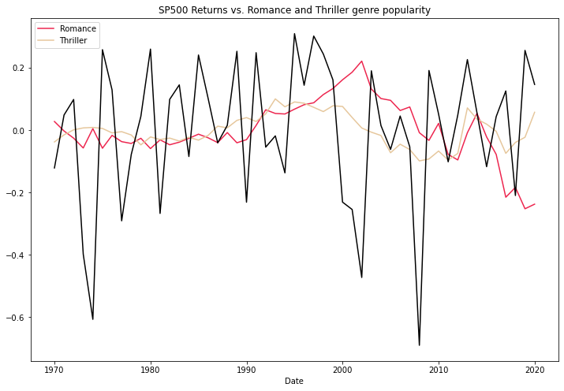

```python
plt.title("SP500 Returns vs. Romance and Thriller genre popularity")
plt.xlabel("Date")
plt.plot(romance_excess_df, color = PINK, label = "Romance")
plt.plot(thriller_excess_df, color = ORANGE, label = "Thriller")
plt.plot(sp500_return_norm_df, color = "black")
plt.legend(loc = "upper left")
plt.show()
```

The magnitude of correlation is not substantial enough to make predictive or diagnostic decisions on.

However, while the popularity of a particular genre may not correlate well with a general market index such as the S&P 500, perhaps it correlates well with the stock prices of individual companys. Particularly, movie related companies may have a more noticable correlation with genre popularity.

## Beyond the S&P 500

Below, I repeat the same tidying, normalization, and exploratory process as I did above with S&P 500 data on the share price data for 3 popular movie related brands: AMC, Cinemark, and IMAX. I also include Netflix, a broader media company.

Below, I read in the dataset, calculate the returns, and normalize the returns.

```python
# AMC
amc_df = pd.read_csv("AMC.csv")
amc_df["Date"] = pd.to_datetime(amc_df["Date"])
amc_df = amc_df[amc_df["Date"] > datetime.datetime(2013, 12, 17, 0, 0)] # dates after AMC IPO

amc_returns_df = get_annual_returns_df(amc_df)
amc_returns_norm_df = get_normalized_returns_df(amc_returns_df)

# Cinemark
cnk_df = pd.read_csv("CNK.csv")
cnk_df["Date"] = pd.to_datetime(cnk_df["Date"])
cnk_df = cnk_df[cnk_df["Date"] > datetime.datetime(2007, 4, 1, 0, 0)] # dates after Cinemark IPO

cnk_returns_df = get_annual_returns_df(cnk_df)
cnk_returns_norm_df = get_normalized_returns_df(cnk_returns_df)

# IMAX
imax_df = pd.read_csv("IMAX.csv")
imax_df["Date"] = pd.to_datetime(imax_df["Date"])
imax_df = imax_df[imax_df["Date"] > datetime.datetime(1994, 6, 1, 0, 0)] # dates after IMAX IPO

imax_returns_df = get_annual_returns_df(imax_df)
imax_returns_norm_df = get_normalized_returns_df(imax_returns_df)

# Netflix
netflix_df = pd.read_csv("NFLX.csv")
netflix_df["Date"] = pd.to_datetime(netflix_df["Date"])
netflix_df = netflix_df[netflix_df["Date"] > datetime.datetime(2002, 6, 1, 0, 0)] # dates after Netflix IPO

netflix_returns_df = get_annual_returns_df(netflix_df)
netflix_returns_norm_df = get_normalized_returns_df(netflix_returns_df)
```

Below is a chart of the normalized stock returns for these four companies:

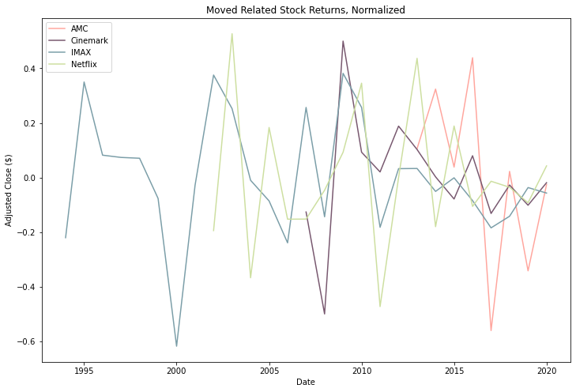

```python
# plot stock returns over time
plt.title("Moved Related Stock Returns, Normalized")
plt.xlabel("Date")
plt.ylabel("Adjusted Close ($)")
plt.plot(amc_returns_norm_df, color = RED, label = "AMC")
plt.plot(cnk_returns_norm_df, color = PURPLE, label = "Cinemark")
plt.plot(imax_returns_norm_df, color = BLUE, label = "IMAX")
plt.plot(netflix_returns_norm_df, color = YELLOW, label = "Netflix")
plt.legend(loc = "upper left")
plt.show()
```

Now, I'll calculate the correlations between returns and genre popularity excess for all stock-genre combinations.

```python
# AMC
amc_corr_df = pd.DataFrame(data = {
    "Genre": ["Comedy", "Horror", "Romance", "Action", "Thriller", "Drama", "Mystery"],
    "Correlation": [
        get_corr(amc_returns_norm_df, comedy_excess_df),
        get_corr(amc_returns_norm_df, horror_excess_df),
        get_corr(amc_returns_norm_df, romance_excess_df),
        get_corr(amc_returns_norm_df, action_excess_df),
        get_corr(amc_returns_norm_df, thriller_excess_df),
        get_corr(amc_returns_norm_df, drama_excess_df),
        get_corr(amc_returns_norm_df, mystery_excess_df)
    ]
})
amc_corr_df = amc_corr_df.set_index("Genre")
amc_corr_df
```

| Genre | Correlation |
| --- | --- |
| Comedy | 0.496530 |
| Horror | 0.265971 |
| Romance | 0.704624 |
| Action | -0.288611 |
| Thriller | 0.574127 |
| Drama | 0.362676 |
| Mystery | 0.494664 |

```python
# Cinemax
cnk_corr_df = pd.DataFrame(data = {
    "Genre": ["Comedy", "Horror", "Romance", "Action", "Thriller", "Drama", "Mystery"],
    "Correlation": [
        get_corr(cnk_returns_norm_df, comedy_excess_df),
        get_corr(cnk_returns_norm_df, horror_excess_df),
        get_corr(cnk_returns_norm_df, romance_excess_df),
        get_corr(cnk_returns_norm_df, action_excess_df),
        get_corr(cnk_returns_norm_df, thriller_excess_df),
        get_corr(cnk_returns_norm_df, drama_excess_df),
        get_corr(cnk_returns_norm_df, mystery_excess_df)
    ]
})
cnk_corr_df = cnk_corr_df.set_index("Genre")
cnk_corr_df
```

| Genre | Correlation |
| --- | --- |
| Comedy | 0.311230 |
| Horror | 0.206317 |
| Romance | 0.062896 |
| Action | 0.203407 |
| Thriller | 0.039310 |
| Drama | 0.232633 |
| Mystery | 0.093013 |

```python
# IMAX
imax_corr_df = pd.DataFrame(data = {
    "Genre": ["Comedy", "Horror", "Romance", "Action", "Thriller", "Drama", "Mystery"],
    "Correlation": [
        get_corr(imax_returns_norm_df, comedy_excess_df),
        get_corr(imax_returns_norm_df, horror_excess_df),
        get_corr(imax_returns_norm_df, romance_excess_df),
        get_corr(imax_returns_norm_df, action_excess_df),
        get_corr(imax_returns_norm_df, thriller_excess_df),
        get_corr(imax_returns_norm_df, drama_excess_df),
        get_corr(imax_returns_norm_df, mystery_excess_df)
    ]
})
imax_corr_df = imax_corr_df.set_index("Genre")
imax_corr_df
```

| Genre | Correlation |
| --- | --- |
| Comedy | 0.118378 |
| Horror | -0.091485 |
| Romance | 0.173466 |
| Action | 0.163239 |
| Thriller | -0.069014 |
| Drama | 0.133841 |
| Mystery | 0.020163 |

```python
# Netflix
netflix_corr_df = pd.DataFrame(data = {
    "Genre": ["Comedy", "Horror", "Romance", "Action", "Thriller", "Drama", "Mystery"],
    "Correlation": [
        get_corr(netflix_returns_norm_df, comedy_excess_df),
        get_corr(netflix_returns_norm_df, horror_excess_df),
        get_corr(netflix_returns_norm_df, romance_excess_df),
        get_corr(netflix_returns_norm_df, action_excess_df),
        get_corr(netflix_returns_norm_df, thriller_excess_df),
        get_corr(netflix_returns_norm_df, drama_excess_df),
        get_corr(netflix_returns_norm_df, mystery_excess_df)
    ]
})
netflix_corr_df = netflix_corr_df.set_index("Genre")
netflix_corr_df
```

| Genre | Correlation |
| --- | --- |
| Comedy | 0.143252 |
| Horror | -0.208389 |
| Romance | 0.068113 |
| Action | -0.006419 |
| Thriller | 0.245848 |
| Drama | 0.159976 |
| Mystery | 0.110056 |

Below, are all the calculated correlations:

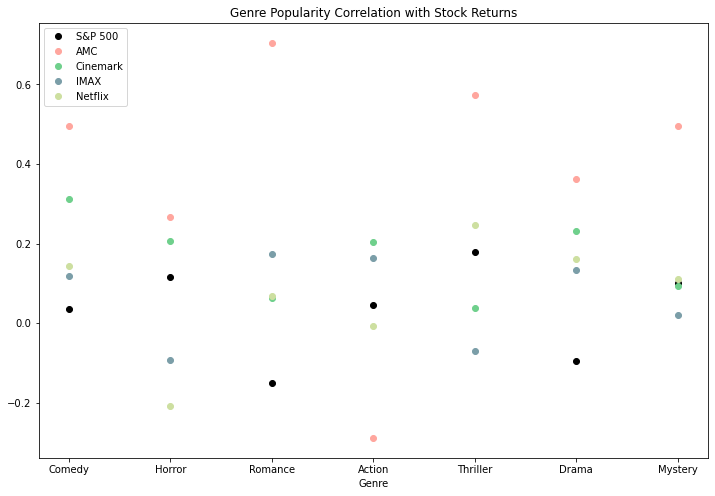

```python
plt.title("Genre Popularity Correlation with Stock Returns")
plt.xlabel("Genre")
plt.plot(spy_corr_df, "o", color = "black", label = "S&P 500")
plt.plot(amc_corr_df, "o", color = RED, label = "AMC")
plt.plot(cnk_corr_df, "o", color = GREEN, label = "Cinemark")
plt.plot(imax_corr_df, "o", color = BLUE, label = "IMAX")
plt.plot(netflix_corr_df, "o", color = YELLOW, label = "Netflix")
plt.legend(loc = "upper left")
plt.show()
```

These results are interesting. It appears that AMC's returns strongly positively correlate with the popularity of the Romance and Thriller genres with respective correlation coefficients of 0.705 and 0.574. In fact, in general, AMC's returns correlate more strongly with genre popularity than another other movie or media company.

Below, I've plotted the popularity of the Romance and Thriller genres against AMC's stock returns.

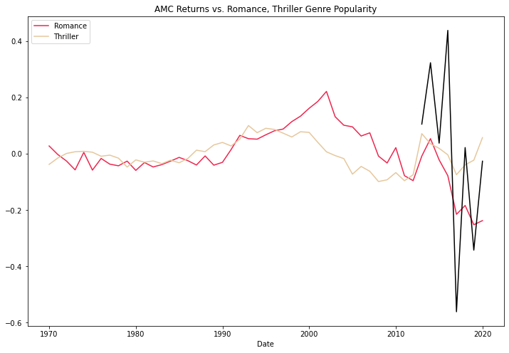

```python
plt.title("AMC Returns vs. Romance, Thriller Genre Popularity")
plt.xlabel("Date")
plt.plot(romance_excess_df, color = PINK, label = "Romance")
plt.plot(thriller_excess_df, color = ORANGE, label = "Thriller")
plt.plot(amc_returns_norm_df, color = "black")
plt.legend(loc = "upper left")
plt.show()
```

## Regression to Predict AMC's Returns

With a correlation of 0.705 and 0.574, lets see if we can predict AMC's returns for 2020 based on the popularity of the Romance and Thriller genres.

Below, I take the normalized count of Romance/Thriller movies, and fit it to the actual Adj. Close of AMC stock from 2013 to 2020. Then, I utilize the normalized count to determine predicted stock price for the same duration.

[Read More: Using Linear Regression, KNN, and SVMs to predict Netflix Stock price](https://towardsai.net/p/machine-learning/netflix-stock-prediction-model-a-comparative-study-of-linear-regression-k-nearest-neighbor-knn-4527ff17939b)

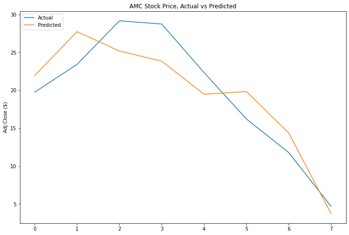

```python
romance_count_norm_df2 = romance_count_norm_df.reset_index()
romance_count_norm_df2 = romance_count_norm_df2[romance_count_norm_df2["startYear"] > 2012] # start at 2013 date

thriller_count_norm_df2 = thriller_count_norm_df.reset_index()
thriller_count_norm_df2 = thriller_count_norm_df2[thriller_count_norm_df2["startYear"] > 2012] # start at 2013 date

rom_e = romance_count_norm_df2["tconst"]
thr_e = thriller_count_norm_df2["tconst"]

amc_df["Date"] = pd.to_datetime(amc_df["Date"])
amc_df2 = amc_df.set_index("Date")

amc_df_yearly = amc_df2.Close.resample('Y').mean() # resample to get yearly data
closes = np.array(amc_df_yearly)

regression_df = pd.DataFrame(data = { # create df for regression
    "Romance": rom_e,
    "Thriller": thr_e,
    "Adj Close": closes
})

X = regression_df[["Romance", "Thriller"]]
Y = regression_df["Adj Close"]
model = linear_model.LinearRegression() # create regression model

model.fit(X, Y)

regression_df = regression_df.reset_index()
predictions = []
for index, row in regression_df.iterrows():
    predict = model.predict([[ row["Romance"], row["Thriller"]]])
    predictions.append(predict)


plt.title("AMC Stock Price, Actual vs Predicted")
plt.ylabel("Adj Close ($)")
plt.plot(regression_df["Adj Close"], label = "Actual")
plt.plot(predictions, label = "Predicted")
plt.legend(loc = "upper left")
plt.show()
```

The actual and predicted values correlate closely.

## Conclusion

The initial investigation into whether a genre's popularity correlates with economic activity resulted in unsubstantial correlations that were not useful for predictive or diagnostic purposes. However, when looking at specific companies instead of the general market, there was an interesting correlation between the Romance and Thriller genre's popularity and AMC's stock returns.

A correlation of 0.705 and 0.574 respectively for the Romance and Thriller genres is substantial enough to warrant predictive analysis. Using the normalized count for Romance and Thriller movies, I fitted a Linear Regression model to the actual share price. Then, I used the normalized counts to predict the Stock price. The predictions were surprisingly accurate.